# X-linked MethDep CG genes are more methylated in oocytes than in sperm

Figures 7E + 7F

```r
library("tidyverse")
library("ComplexHeatmap")
library("CTexploreR")
library("circlize")
library("SummarizedExperiment")
library("SingleCellExperiment")
library("DESeq2")
```

```r
CT_genes_X_met <- CT_genes %>%
  filter(CT_gene_type == "CT_gene") %>%
  filter(X_linked, regulated_by_methylation) %>%
  pull(external_gene_name)

gamete_colors <- c("MII oocytes" = "deeppink",
               "Sperm"= "steelblue")

MethDep_colors <- c("MethDep" = "indianred2",
"Non-MethDep"= "cyan4")
```

scWGBS data from

[Single-cell DNA methylome sequencing of human preimplantation embryos. Nat Genet 50, 12–19 (2018). Zhu, P., Guo, H., Ren, Y. et al.](https://doi.org/10.1038/s41588-017-0007-6)

# Oocytes vs Sperm

## X-linked MethDep CT genes

```r
non_missing_values_thr <- 5
```

Kept genes with at least 5 methylation value per cell type

Removed Y-sperm cells from dataset for analysis of X-linked genes!

```r
mean_met <- CTdata::mean_methylation_in_embryo()
mean_met <- mean_met[rowRanges(mean_met)$external_gene_name %in% CT_genes_X_met,]


# => Removed Y-sperm cells from dataset for analysis of X-linked genes!
Y_sperm_cells <- as_tibble(colData(mean_met), rownames = "cell") %>%
  filter(Genotype.of.the.embryo == "Y") %>%
  pull(cell)

bilan_oocytes <- as_tibble(assay(mean_met), rownames = "gene") %>%
  pivot_longer(names_to = "cell", values_to = "met", -gene) %>%
  left_join(as_tibble(colData(mean_met), rownames = "cell")) %>%
  filter(!low_quality) %>%
  #filter(!cell %in% Y_sperm_cells) %>%
  filter(Genotype.of.the.embryo != "XXX") %>%
  filter(Stage %in% c("MII Oocyte")) %>%
  dplyr::select(gene, cell, met) %>%
  pivot_wider(names_from = cell, values_from = met)

bilan_sperm <- as_tibble(assay(mean_met), rownames = "gene") %>%
  pivot_longer(names_to = "cell", values_to = "met", -gene) %>%
  left_join(as_tibble(colData(mean_met), rownames = "cell")) %>%
  filter(!cell %in% Y_sperm_cells) %>%
  filter(!low_quality) %>%
  filter(Stage %in% c("Sperm"))  %>%
  dplyr::select(gene, cell, met) %>%
  pivot_wider(names_from = cell, values_from = met)

mat_oocytes <- as.matrix(bilan_oocytes[,-1])
rownames(mat_oocytes) <- bilan_oocytes$gene

mat_sperm <- as.matrix(bilan_sperm[,-1])
rownames(mat_sperm) <- bilan_sperm$gene


# Remove genes with too many missing values
# Genes must have at least met values in 5 oocytes and in 5 sperm cells
genes_selected1 <- tibble(gene = rownames(mat_oocytes),
                       mean_met = rowMeans(mat_oocytes, na.rm = TRUE),
                       non_missing_values = rowSums(!is.na(mat_oocytes)) ) %>%
  arrange(desc(non_missing_values)) %>%
  filter(non_missing_values >= non_missing_values_thr) %>%
  pull(gene)

genes_selected2 <- tibble(gene = rownames(mat_sperm),
                       mean_met = rowMeans(mat_sperm, na.rm = TRUE),
                       non_missing_values = rowSums(!is.na(mat_sperm)) ) %>%
  arrange(desc(non_missing_values)) %>%
  filter(non_missing_values >= non_missing_values_thr) %>%
  pull(gene)

genes_selected <- BiocGenerics::intersect(genes_selected1, genes_selected2)

# Order by decreasing methylation levels in oocytes
gene_ordered <- tibble(gene = rownames(mat_oocytes[genes_selected,]),
                       mean_met = rowMeans(mat_oocytes[genes_selected,], na.rm = TRUE)) %>%
  arrange(desc(mean_met)) %>%
  pull(gene)

gene_reordered <- gene_ordered
# SPANXD comes first as also methylated in sperm
if ("SPANXD" %in% gene_ordered){
  gene_reordered <- c( gene_ordered[-which(gene_ordered == "SPANXD")], "SPANXD")
}
```

40 genes kept.

```r
X_linked_CT_genes_selected <- gene_reordered

h_oocytes <- Heatmap(mat_oocytes[gene_reordered, ],
               column_title = "MII oocytes",
               name = 'Met',
               col = colorRamp2(c(1:100),colorRampPalette(
                 c("moccasin","dodgerblue4"))(100)),
               na_col = "gray80",
                     left_annotation = rowAnnotation(
                       met = anno_block(
                         gp = gpar(fill = c(MethDep_colors[1]),
                                   face = "bold",
                                   col = "black", lwd = 0.2),
                         width = unit(c(0.5), "cm"),
                         labels = "X-linked MethDep",
                         labels_gp = gpar(col = "white", fontsize = 10))),
               clustering_method_rows = "ward.D",
               cluster_rows = FALSE,
               cluster_columns = FALSE,
               show_row_names = FALSE,
               show_column_names = TRUE,
               show_heatmap_legend = TRUE,
               show_row_dend = FALSE,
               row_names_gp = gpar(fontsize = 5),
               column_names_gp = gpar(fontsize = 0),
               column_names_side = "bottom",
               row_names_side = "left",
                 width = unit(4, "cm"),
                 height = unit(6, "cm"))

gene_to_label <- c("MAGEC2", "DDX53", "MAGEB16", "MAGEB6", "TEX13C", "PASD1", "SSX1", "CT45A10", "SPANXD", "VCX", "GAGE2A")
ind_to_label <- which(rownames(mat_sperm[gene_reordered, ]) %in% gene_to_label)
ha <- rowAnnotation(lab = anno_mark(at = ind_to_label,
                                        labels = rownames(mat_sperm[gene_reordered, ][ind_to_label,]),
                                        labels_gp = gpar(fontsize = 6)))


h_sperm <- Heatmap(mat_sperm[gene_reordered, ],
                   column_title = "Sperm",
                   name = 'Met',
                   col = colorRamp2(c(1:100),colorRampPalette(
                     c("moccasin","dodgerblue4"))(100)),
                   na_col = "gray80",
                   clustering_method_rows = "ward.D",
                   cluster_rows = FALSE,
                   cluster_columns = FALSE,
                   show_row_names = TRUE,
                   show_column_names = TRUE,
                   show_heatmap_legend = TRUE,
                   show_row_dend = FALSE,
                   row_names_gp = gpar(fontsize = 6),
                   column_names_gp = gpar(fontsize = 0),
                   column_names_side = "bottom",
                   row_names_side = "left",
                   right_annotation = ha,
                 width = unit(4, "cm"),
                 height = unit(6, "cm"))

ht_list <- h_oocytes + h_sperm

pdf(file = "../figs/Fig7E.pdf", width = 6, height = 4)
draw(ht_list, merge_legend = TRUE, ht_gap = unit(0.1, "cm"))
dev.off()
```

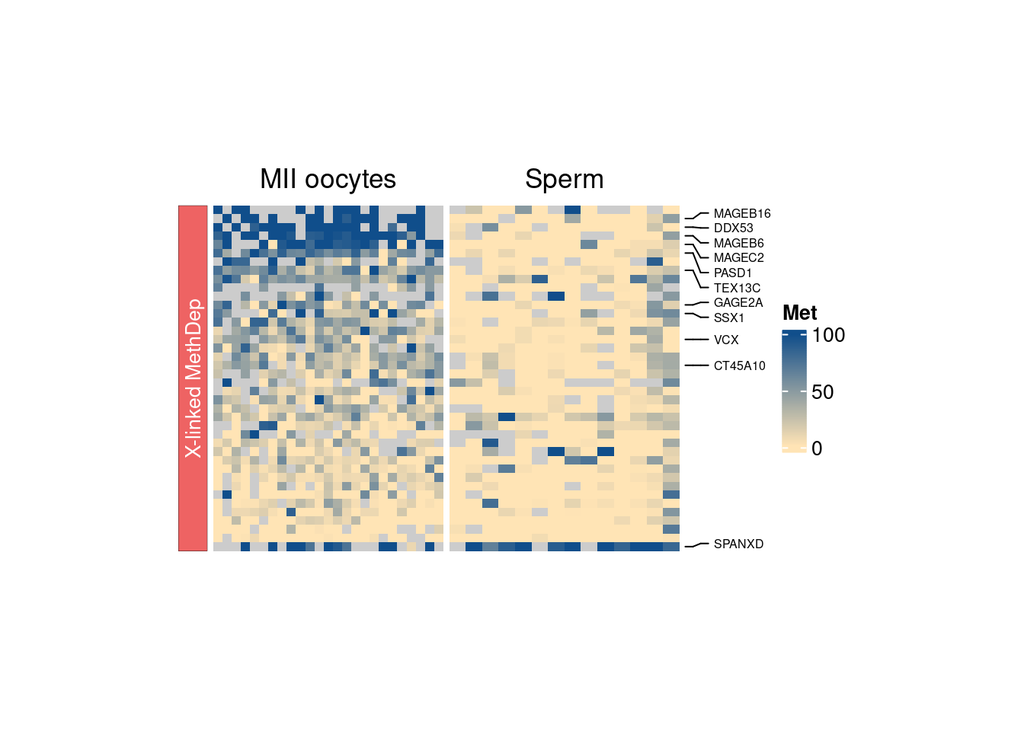

```r
draw(ht_list, merge_legend = TRUE, ht_gap = unit(0.1, "cm"))
```

### Quantification

#### based on mean methylation values

Calculated the **mean** methylation of each gene in MII oocytes and in sperm

```r
bilan_mean_CT_prom <- rbind(
  tibble(gene = gene_reordered,
       mean_met = rowMeans(mat_oocytes[gene_reordered, ], na.rm = TRUE)) %>%
  mutate(cell_type = "MII oocytes"),
  tibble(gene = gene_reordered,
       mean_met = rowMeans(mat_sperm[gene_reordered, ], na.rm = TRUE)) %>%
  mutate(cell_type = "Sperm"))

DT::datatable(bilan_mean_CT_prom)
```

|  | gene | mean_met | cell_type |
| --- | --- | --- | --- |
| 1 | SPANXC | 100 | MII oocytes |
| 2 | MAGEB16 | 99.2063492063492 | MII oocytes |
| 3 | DDX53 | 98.08823529411765 | MII oocytes |
| 4 | MAGEB6 | 94.1722582972583 | MII oocytes |
| 5 | MAGEC2 | 84.96306020066889 | MII oocytes |
| 6 | PASD1 | 63.21450657087858 | MII oocytes |
| 7 | TGIF2LX | 53.08441558441558 | MII oocytes |
| 8 | TEX13C | 49.56043050790694 | MII oocytes |
| 9 | PAGE1 | 46.36686785806668 | MII oocytes |
| 10 | MAGEA2 | 45.3594696969697 | MII oocytes |

[output cut: 70 more lines]

```r
knitr::kable(bilan_mean_CT_prom %>%
  group_by(cell_type) %>%
  dplyr::summarise(Mean_prom_met = mean(mean_met), Median_prom_met = median(mean_met)))
```

| cell_type | Mean_prom_met | Median_prom_met |
| --- | --- | --- |
| MII oocytes | 36.69368 | 29.47333 |
| Sperm | 11.12655 | 6.75466 |

t.test: Is methylation higher in oocytes than in sperm ?

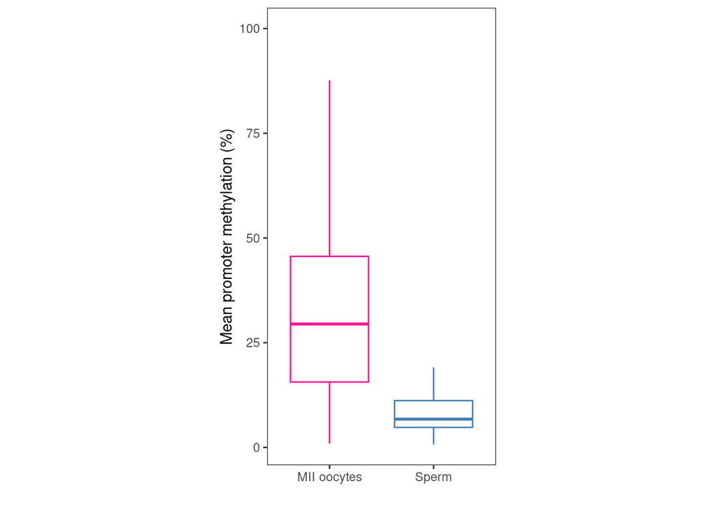

```r
bilan_mean_CT_prom %>%
  ggplot(aes(x = cell_type, y = mean_met, color = cell_type)) +
  geom_boxplot(alpha = 0) +
  scale_color_manual(values = gamete_colors) +
  theme_bw() +
  theme(aspect.ratio = 2,
        panel.grid.minor = element_blank(),
        panel.grid.major = element_blank(),
        legend.position = "none") +
  ylab("Mean promoter methylation (%)") +
  xlab('')
```

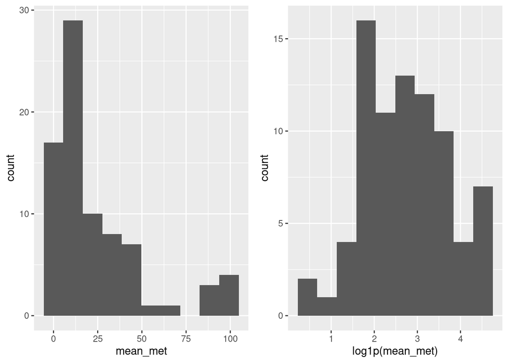

```r
gridExtra::grid.arrange(bilan_mean_CT_prom %>%
                          ggplot(aes(x = mean_met)) +
                          geom_histogram(bins = 10),
                        bilan_mean_CT_prom %>%
                          ggplot(aes(x = log1p(mean_met))) +
                          geom_histogram(bins = 10), ncol = 2)
```

```r
# bilan_mean_CT_prom %>% filter(cell_type == "MII oocytes") %>% pull(gene)
# bilan_mean_CT_prom %>% filter(cell_type == "Sperm") %>% pull(gene)
```

t.test

```r
t.test(bilan_mean_CT_prom %>% filter(cell_type == "MII oocytes") %>% pull(mean_met) %>% log1p(),
       bilan_mean_CT_prom %>% filter(cell_type == "Sperm") %>% pull(mean_met) %>% log1p())
```

```
##
##  Welch Two Sample t-test
##
## data:  bilan_mean_CT_prom %>% filter(cell_type == "MII oocytes") %>% pull(mean_met) %>% log1p() and bilan_mean_CT_prom %>% filter(cell_type == "Sperm") %>% pull(mean_met) %>% log1p()
## t = 6.3029, df = 74.884, p-value = 1.831e-08
## alternative hypothesis: true difference in means is not equal to 0
## 95 percent confidence interval:
##  0.7780242 1.4971233
## sample estimates:
## mean of x mean of y
##  3.316369  2.178795
```

t.test but one-side

```r
t.test(bilan_mean_CT_prom %>% filter(cell_type == "MII oocytes") %>% pull(mean_met) %>% log1p(),
       bilan_mean_CT_prom %>% filter(cell_type == "Sperm") %>% pull(mean_met) %>% log1p(),
       alternative = "greater")
```

```
##
##  Welch Two Sample t-test
##
## data:  bilan_mean_CT_prom %>% filter(cell_type == "MII oocytes") %>% pull(mean_met) %>% log1p() and bilan_mean_CT_prom %>% filter(cell_type == "Sperm") %>% pull(mean_met) %>% log1p()
## t = 6.3029, df = 74.884, p-value = 9.153e-09
## alternative hypothesis: true difference in means is greater than 0
## 95 percent confidence interval:
##  0.8369871       Inf
## sample estimates:
## mean of x mean of y
##  3.316369  2.178795
```

t.test paired

```r
t.test(bilan_mean_CT_prom %>% filter(cell_type == "MII oocytes") %>% pull(mean_met) %>% log1p(),
       bilan_mean_CT_prom %>% filter(cell_type == "Sperm") %>% pull(mean_met) %>% log1p(),
       paired = TRUE)
```

```
##
##  Paired t-test
##
## data:  bilan_mean_CT_prom %>% filter(cell_type == "MII oocytes") %>% pull(mean_met) %>% log1p() and bilan_mean_CT_prom %>% filter(cell_type == "Sperm") %>% pull(mean_met) %>% log1p()
## t = 8.0499, df = 39, p-value = 8.121e-10
## alternative hypothesis: true mean difference is not equal to 0
## 95 percent confidence interval:
##  0.8517362 1.4234113
## sample estimates:
## mean difference
##        1.137574
```

t.test one-side paired

```r
t.test(bilan_mean_CT_prom %>% filter(cell_type == "MII oocytes") %>% pull(mean_met) %>% log1p(),
       bilan_mean_CT_prom %>% filter(cell_type == "Sperm") %>% pull(mean_met) %>% log1p(),
       alternative = "greater",
       paired = TRUE)
```

```
##
##  Paired t-test
##
## data:  bilan_mean_CT_prom %>% filter(cell_type == "MII oocytes") %>% pull(mean_met) %>% log1p() and bilan_mean_CT_prom %>% filter(cell_type == "Sperm") %>% pull(mean_met) %>% log1p()
## t = 8.0499, df = 39, p-value = 4.061e-10
## alternative hypothesis: true mean difference is greater than 0
## 95 percent confidence interval:
##  0.8994748       Inf
## sample estimates:
## mean difference
##        1.137574
```

## Other X-linked genes

All X-linked genes other than MethDep CT genes

Kept genes with at least 5 methylation value per cell type

Removed Y-sperm cells from dataset for analysis of X-linked genes!

```r
mean_met <- CTdata::mean_methylation_in_embryo()
mean_met_X_chr <- mean_met[rowRanges(mean_met)$chr == "X", ]

CTP_genes_X_met <- all_genes %>%
  filter(regulated_by_methylation) %>%
  filter(CT_gene_type == "CTP_gene") %>%
  pull(external_gene_name)

X_linked_not_CT <- all_genes %>%
  filter(chr == "X") %>%
  filter(!external_gene_name %in% CT_genes_X_met) %>%
  pull(external_gene_name)

mean_met_X_chr <- mean_met_X_chr[rowRanges(mean_met_X_chr)$external_gene_name %in% X_linked_not_CT,]
```

```r
# => Removed Y-sperm cells from dataset for analysis of X-linked genes!
Y_sperm_cells <- as_tibble(colData(mean_met_X_chr), rownames = "cell") %>%
  filter(Genotype.of.the.embryo == "Y") %>%
  pull(cell)

bilan_oocytes <- as_tibble(assay(mean_met_X_chr), rownames = "gene") %>%
  pivot_longer(names_to = "cell", values_to = "met", -gene) %>%
  left_join(as_tibble(colData(mean_met_X_chr), rownames = "cell")) %>%
  filter(!low_quality) %>%
  filter(Genotype.of.the.embryo != "XXX") %>%
  filter(Stage %in% c("MII Oocyte")) %>%
  dplyr::select(gene, cell, met) %>%
  pivot_wider(names_from = cell, values_from = met)

bilan_sperm <- as_tibble(assay(mean_met_X_chr), rownames = "gene") %>%
  pivot_longer(names_to = "cell", values_to = "met", -gene) %>%
  left_join(as_tibble(colData(mean_met_X_chr), rownames = "cell")) %>%
  filter(!cell %in% Y_sperm_cells) %>%
  filter(!low_quality) %>%
  filter(Stage %in% c("Sperm"))  %>%
  dplyr::select(gene, cell, met) %>%
  pivot_wider(names_from = cell, values_from = met)

mat_oocytes <- as.matrix(bilan_oocytes[,-1])
rownames(mat_oocytes) <- bilan_oocytes$gene
mat_sperm <- as.matrix(bilan_sperm[,-1])
rownames(mat_sperm) <- bilan_sperm$gene


# Remove genes with too many missing values
# Genes must have at least met values in 5 oocytes and in 5 sperm cells
genes_selected1 <- tibble(gene = rownames(mat_oocytes),
                       mean_met = rowMeans(mat_oocytes, na.rm = TRUE),
                       non_missing_values = rowSums(!is.na(mat_oocytes)) ) %>%
  arrange(desc(non_missing_values)) %>%
  filter(non_missing_values >= non_missing_values_thr) %>%
  pull(gene)

genes_selected2 <- tibble(gene = rownames(mat_sperm),
                       mean_met = rowMeans(mat_sperm, na.rm = TRUE),
                       non_missing_values = rowSums(!is.na(mat_sperm)) ) %>%
  arrange(desc(non_missing_values)) %>%
  filter(non_missing_values >= non_missing_values_thr) %>%
  pull(gene)

genes_selected <- BiocGenerics::intersect(genes_selected1, genes_selected2)

# Order by decreasing methylation levels in oocytes
gene_ordered <- tibble(gene = rownames(mat_oocytes[genes_selected,]),
                       mean_met = rowMeans(mat_oocytes[genes_selected,], na.rm = TRUE)) %>%
  arrange(desc(mean_met)) %>%
  pull(gene)

length(gene_ordered)
```

```
## [1] 780
```

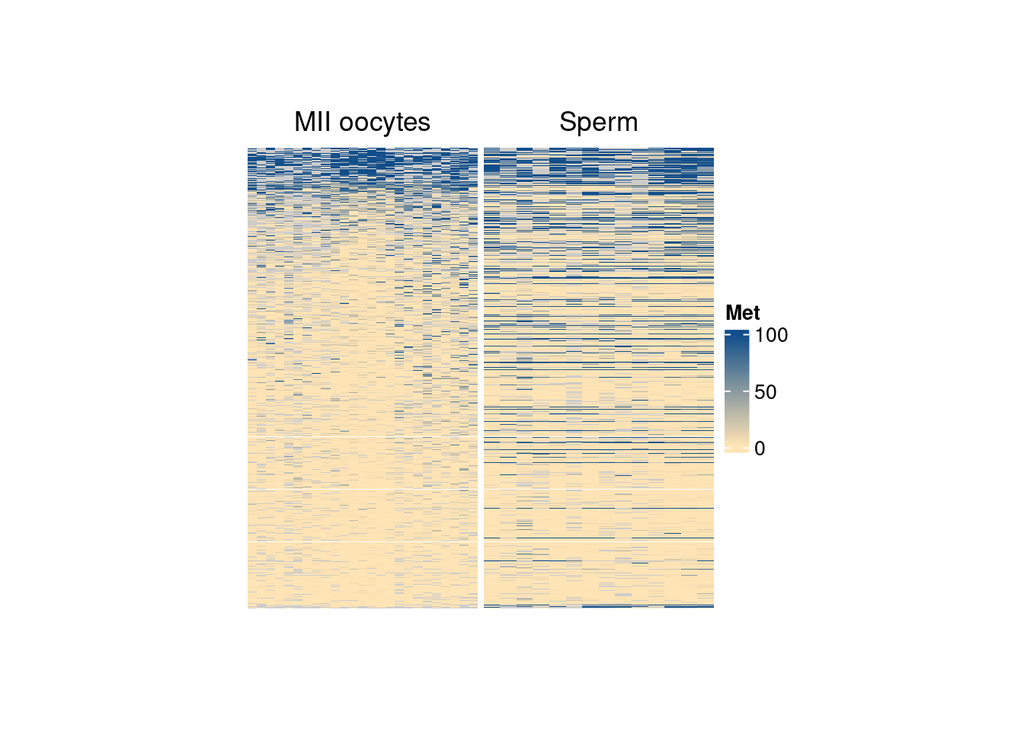

```r
h_oocytes <- Heatmap(mat_oocytes[gene_ordered, ],
                     column_title = "MII oocytes",
                     name = 'Met',
                     col = colorRamp2(c(1:100),colorRampPalette(
                       c("moccasin","dodgerblue4"))(100)),
                     na_col = "gray80",
                     clustering_method_rows = "ward.D",
                     cluster_rows = FALSE,
                     cluster_columns = FALSE,
                     show_row_names = TRUE,
                     show_column_names = TRUE,
                     show_heatmap_legend = TRUE,
                     show_row_dend = FALSE,
                     row_names_gp = gpar(fontsize = 0),
                     column_names_gp = gpar(fontsize = 0),
                     column_names_side = "bottom",
                     row_names_side = "left",
                     width = unit(4, "cm"),
                     height = unit(8, "cm"))


h_sperm <- Heatmap(mat_sperm[gene_ordered, ],
                   column_title = "Sperm",
                   name = 'Met',
                   col = colorRamp2(c(1:100),colorRampPalette(
                     c("moccasin","dodgerblue4"))(100)),
                   na_col = "gray80",
                   clustering_method_rows = "ward.D",
                   cluster_rows = FALSE,
                   cluster_columns = FALSE,
                   show_row_names = TRUE,
                   show_column_names = TRUE,
                   show_heatmap_legend = TRUE,
                   show_row_dend = FALSE,
                   row_names_gp = gpar(fontsize = 0),
                   column_names_gp = gpar(fontsize = 0),
                   column_names_side = "bottom",
                   row_names_side = "left",
                   width = unit(4, "cm"),
                   height = unit(8, "cm"))

ht_list1 <- h_oocytes + h_sperm

draw(ht_list1, merge_legend = TRUE, ht_gap = unit(0.1, "cm"))
```

idem but cluster by methylation in sperm

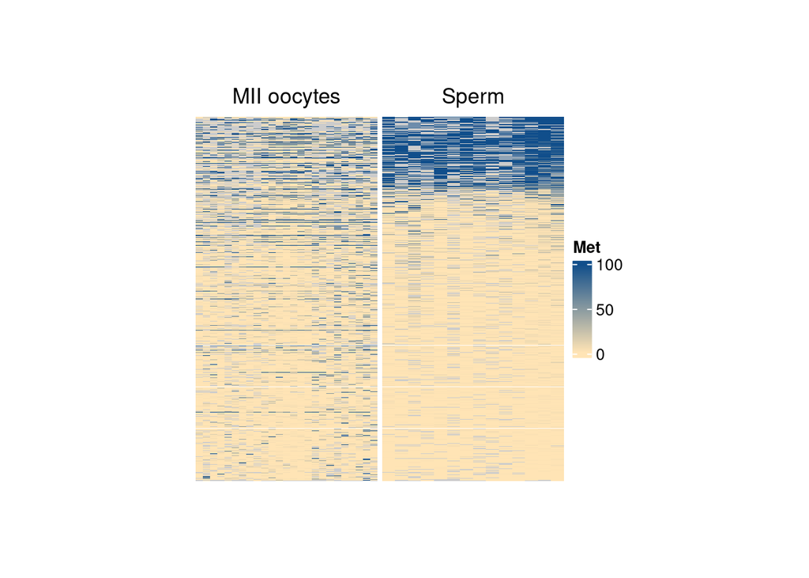

```r
# Order by decreasing methylation levels in sperm
gene_ordered <- tibble(gene = rownames(mat_sperm[genes_selected,]),
                       mean_met = rowMeans(mat_sperm[genes_selected,], na.rm = TRUE)) %>%
  arrange(desc(mean_met)) %>%
  pull(gene)


h_oocytes <- Heatmap(mat_oocytes[gene_ordered, ],
                     column_title = "MII oocytes",
                     name = 'Met',
                     col = colorRamp2(c(1:100),colorRampPalette(
                       c("moccasin","dodgerblue4"))(100)),
                     na_col = "gray80",
                     clustering_method_rows = "ward.D",
                     cluster_rows = FALSE,
                     cluster_columns = FALSE,
                     show_row_names = TRUE,
                     show_column_names = TRUE,
                     show_heatmap_legend = TRUE,
                     show_row_dend = FALSE,
                     row_names_gp = gpar(fontsize = 0),
                     column_names_gp = gpar(fontsize = 0),
                     column_names_side = "bottom",
                     row_names_side = "left",
                     width = unit(4, "cm"),
                     height = unit(8, "cm"))


h_sperm <- Heatmap(mat_sperm[gene_ordered, ],
                   column_title = "Sperm",
                   name = 'Met',
                   col = colorRamp2(c(1:100),colorRampPalette(
                     c("moccasin","dodgerblue4"))(100)),
                   na_col = "gray80",
                   clustering_method_rows = "ward.D",
                   cluster_rows = FALSE,
                   cluster_columns = FALSE,
                   show_row_names = TRUE,
                   show_column_names = TRUE,
                   show_heatmap_legend = TRUE,
                   show_row_dend = FALSE,
                   row_names_gp = gpar(fontsize = 0),
                   column_names_gp = gpar(fontsize = 0),
                   column_names_side = "bottom",
                   row_names_side = "left",
                   width = unit(4, "cm"),
                   height = unit(8, "cm"))

ht_list2 <- h_oocytes + h_sperm

draw(ht_list2, merge_legend = TRUE, ht_gap = unit(0.1, "cm"))
```

#### t.test

t.test Is methylation higher in oocytes than in sperm ?

```r
gene_reordered <- gene_ordered
bilan_mean_other_prom <- rbind(
  tibble(gene = gene_reordered,
       mean_met = rowMeans(mat_oocytes[gene_reordered, ], na.rm = TRUE)) %>%
  mutate(cell_type = "MII oocytes"),
  tibble(gene = gene_reordered,
       mean_met = rowMeans(mat_sperm[gene_reordered, ], na.rm = TRUE)) %>%
  mutate(cell_type = "Sperm"))


DT::datatable(bilan_mean_other_prom)
```

|  | gene | mean_met | cell_type |
| --- | --- | --- | --- |
| 1 | MAGEB4 | 1.555555555555556 | MII oocytes |
| 2 | BMP15 | 7.142857142857142 | MII oocytes |
| 3 | PCYT1B-AS1 | 13.67647058823529 | MII oocytes |
| 4 | MAGEB5 | 95.3125 | MII oocytes |
| 5 | CASK-AS1 | 100 | MII oocytes |
| 6 | ALAS2 | 31.11111111111111 | MII oocytes |
| 7 | MAGEC3 | 88.11111111111111 | MII oocytes |
| 8 | LINC02154 | 28.57142857142857 | MII oocytes |
| 9 | RIPPLY1 | 33.33333333333334 | MII oocytes |
| 10 | LINC01186 | 9.646336996336997 | MII oocytes |

[output cut: 1550 more lines]

```r
knitr::kable(bilan_mean_other_prom %>%
  group_by(cell_type) %>%
  dplyr::summarise(Mean_prom_met = mean(mean_met), Median_prom_met = median(mean_met)))
```

| cell_type | Mean_prom_met | Median_prom_met |
| --- | --- | --- |
| MII oocytes | 14.66202 | 5.019706 |
| Sperm | 21.10708 | 2.394055 |

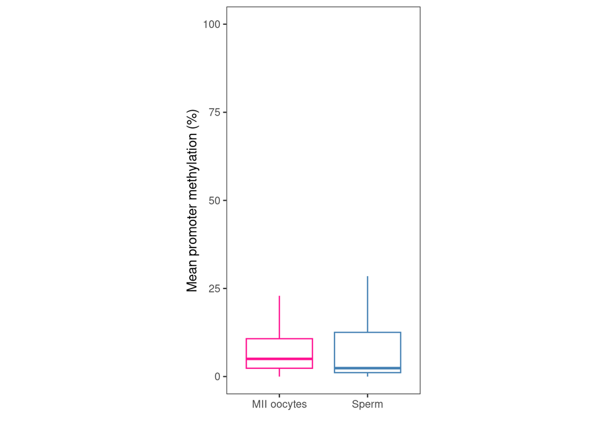

```r
bilan_mean_other_prom %>%
  ggplot(aes(x = cell_type, y = mean_met, color = cell_type)) +
  geom_boxplot(alpha = 0) +
  scale_color_manual(values = gamete_colors) +
  theme_bw() +
  theme(aspect.ratio = 2,
        panel.grid.minor = element_blank(),
        panel.grid.major = element_blank(),
        legend.position = "none") +
  ylab("Mean promoter methylation (%)") +
  xlab('')
```

t.test

```r
t.test(bilan_mean_other_prom %>% filter(cell_type == "MII oocytes") %>% pull(mean_met) %>% log1p(),
       bilan_mean_other_prom %>% filter(cell_type == "Sperm") %>% pull(mean_met) %>% log1p())
```

```
##
##  Welch Two Sample t-test
##
## data:  bilan_mean_other_prom %>% filter(cell_type == "MII oocytes") %>% pull(mean_met) %>% log1p() and bilan_mean_other_prom %>% filter(cell_type == "Sperm") %>% pull(mean_met) %>% log1p()
## t = 2.147, df = 1445.1, p-value = 0.03196
## alternative hypothesis: true difference in means is not equal to 0
## 95 percent confidence interval:
##  0.01230784 0.27274446
## sample estimates:
## mean of x mean of y
##  1.995120  1.852594
```

t.test but one-side

```r
t.test(bilan_mean_other_prom %>% filter(cell_type == "MII oocytes") %>% pull(mean_met) %>% log1p(),
       bilan_mean_other_prom %>% filter(cell_type == "Sperm") %>% pull(mean_met) %>% log1p(),
       alternative = "greater")
```

```
##
##  Welch Two Sample t-test
##
## data:  bilan_mean_other_prom %>% filter(cell_type == "MII oocytes") %>% pull(mean_met) %>% log1p() and bilan_mean_other_prom %>% filter(cell_type == "Sperm") %>% pull(mean_met) %>% log1p()
## t = 2.147, df = 1445.1, p-value = 0.01598
## alternative hypothesis: true difference in means is greater than 0
## 95 percent confidence interval:
##  0.03326499        Inf
## sample estimates:
## mean of x mean of y
##  1.995120  1.852594
```

t.test paired

```r
t.test(bilan_mean_other_prom %>% filter(cell_type == "MII oocytes") %>% pull(mean_met) %>% log1p(),
       bilan_mean_other_prom %>% filter(cell_type == "Sperm") %>% pull(mean_met) %>% log1p(),
       paired = TRUE)
```

```
##
##  Paired t-test
##
## data:  bilan_mean_other_prom %>% filter(cell_type == "MII oocytes") %>% pull(mean_met) %>% log1p() and bilan_mean_other_prom %>% filter(cell_type == "Sperm") %>% pull(mean_met) %>% log1p()
## t = 3.1914, df = 779, p-value = 0.001472
## alternative hypothesis: true mean difference is not equal to 0
## 95 percent confidence interval:
##  0.05486035 0.23019195
## sample estimates:
## mean difference
##       0.1425262
```

t.test one-side paired

```r
t.test(bilan_mean_other_prom %>% filter(cell_type == "MII oocytes") %>% pull(mean_met) %>% log1p(),
       bilan_mean_other_prom %>% filter(cell_type == "Sperm") %>% pull(mean_met) %>% log1p(),
       alternative = "greater",
       paired = TRUE)
```

```
##
##  Paired t-test
##
## data:  bilan_mean_other_prom %>% filter(cell_type == "MII oocytes") %>% pull(mean_met) %>% log1p() and bilan_mean_other_prom %>% filter(cell_type == "Sperm") %>% pull(mean_met) %>% log1p()
## t = 3.1914, df = 779, p-value = 0.0007362
## alternative hypothesis: true mean difference is greater than 0
## 95 percent confidence interval:
##  0.06898154        Inf
## sample estimates:
## mean difference
##       0.1425262
```

## Alltogether

```r
bilan <- rbind(bilan_mean_CT_prom %>% mutate(group = "X-linked CG MethDep"),
bilan_mean_other_prom %>% mutate(group = "X-linked non CG"))

# bilan %>%
#   ggplot(aes(x = cell_type, y = mean_met, color = cell_type)) +
#   geom_boxplot(alpha = 0) +
#   facet_wrap(~ group) +
#   scale_color_manual(values = gamete_colors) +
#   theme_bw() +
#   theme(aspect.ratio = 2,
#         panel.grid.minor = element_blank(),
#         panel.grid.major = element_blank(),
#         legend.position = "none")

bilan$group <- factor(bilan$group)
levels(bilan$group) <- c("X-linked\nCG MethDep","X-linked\nnon CG")

group_colors <- c("X-linked\nCG MethDep" = "indianred2", "X-linked\nnon CG"= "gray40")
fig <- bilan %>%
  ggplot(aes(x = cell_type, y = mean_met, color = group, fill = group)) +
  scale_color_manual(values = group_colors) +
    scale_fill_manual(values = group_colors) +
  geom_boxplot(alpha = 0.2, outliers = FALSE) +
  #facet_wrap(~ group) +
  #scale_color_manual(values = gamete_colors) +
  theme_bw() +
  theme(#aspect.ratio = 2,
        panel.grid.minor = element_blank(),
        panel.grid.major = element_blank(),
        legend.position = "inside",
        legend.position.inside = c(0.75, 0.85),
        legend.key.spacing.y = unit(0.3, 'cm'),
        legend.background = element_blank(),
        #legend.spacing.x = unit(20.0, 'cm'),
        legend.title = element_blank(),
        legend.text = element_text(size = 8),
        axis.title.x = element_blank(),
        axis.title.y = element_text(size = 12),
        axis.text = element_text(size = 12, face = "bold")) +
  ylab("Mean promoter methylation (%)")

pdf(file = paste0("../figs/Fig7F.pdf"), height = 3, width = 3)
fig
dev.off()
```

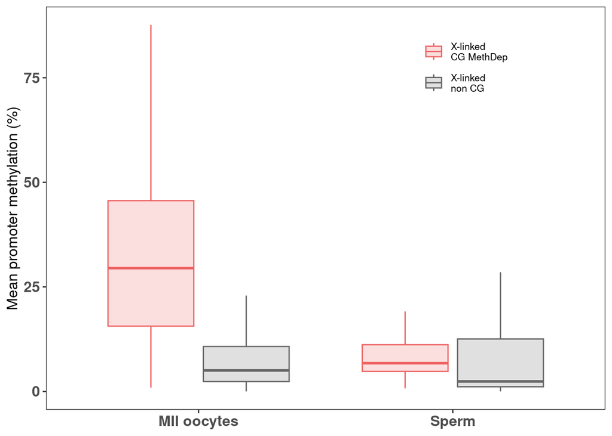

```r
fig
```

## Welch test

Welch test (t.test but set var.equal = FALSE)

*Welch test is more robust than t.tests when the number of sample per group is very different*

For`X-linked MethDep`, methylation is also significantly different between `oocytes` and `sperm`:

```r
bilan <- bilan %>%
  mutate(Group = paste0(group, "_", cell_type)) %>%
  mutate(log_mean_met = log1p(mean_met))


t.test(bilan %>%
         filter(cell_type == "MII oocytes") %>%
         filter(group == "X-linked\nCG MethDep") %>% pull(log_mean_met),
      bilan %>%
         filter(cell_type == "Sperm") %>%
         filter(group == "X-linked\nCG MethDep") %>% pull(log_mean_met),
        var.equal = FALSE)
```

```
##
##  Welch Two Sample t-test
##
## data:  bilan %>% filter(cell_type == "MII oocytes") %>% filter(group == "X-linked\nCG MethDep") %>% pull(log_mean_met) and bilan %>% filter(cell_type == "Sperm") %>% filter(group == "X-linked\nCG MethDep") %>% pull(log_mean_met)
## t = 6.3029, df = 74.884, p-value = 1.831e-08
## alternative hypothesis: true difference in means is not equal to 0
## 95 percent confidence interval:
##  0.7780242 1.4971233
## sample estimates:
## mean of x mean of y
##  3.316369  2.178795
```

For`X-linked Non MethDep`, methylation is also significantly different between `oocytes` ad `sperm`:

```r
t.test(bilan %>%
         filter(cell_type == "MII oocytes") %>%
         filter(group == "X-linked\nnon CG") %>% pull(log_mean_met),
      bilan %>%
         filter(cell_type == "Sperm") %>%
         filter(group == "X-linked\nnon CG") %>% pull(log_mean_met),
      var.equal = FALSE)
```

```
##
##  Welch Two Sample t-test
##
## data:  bilan %>% filter(cell_type == "MII oocytes") %>% filter(group == "X-linked\nnon CG") %>% pull(log_mean_met) and bilan %>% filter(cell_type == "Sperm") %>% filter(group == "X-linked\nnon CG") %>% pull(log_mean_met)
## t = 2.147, df = 1445.1, p-value = 0.03196
## alternative hypothesis: true difference in means is not equal to 0
## 95 percent confidence interval:
##  0.01230784 0.27274446
## sample estimates:
## mean of x mean of y
##  1.995120  1.852594
```

Methylation is highly significantly different in oocytes between `X-linked MethDep` and `X-linked non CG`:

```r
t.test(bilan %>%
         filter(cell_type == "MII oocytes") %>%
         filter(group == "X-linked\nCG MethDep") %>% pull(log_mean_met),
      bilan %>%
         filter(cell_type == "MII oocytes") %>%
         filter(group == "X-linked\nnon CG") %>% pull(log_mean_met),
      var.equal = FALSE)
```

```
##
##  Welch Two Sample t-test
##
## data:  bilan %>% filter(cell_type == "MII oocytes") %>% filter(group == "X-linked\nCG MethDep") %>% pull(log_mean_met) and bilan %>% filter(cell_type == "MII oocytes") %>% filter(group == "X-linked\nnon CG") %>% pull(log_mean_met)
## t = 9.075, df = 45.555, p-value = 8.875e-12
## alternative hypothesis: true difference in means is not equal to 0
## 95 percent confidence interval:
##  1.028110 1.614387
## sample estimates:
## mean of x mean of y
##  3.316369  1.995120
```

```r
# wilcox.test(bilan %>%
#          filter(cell_type == "MII oocytes") %>%
#          filter(group == "X-linked\nCG MethDep") %>% pull(mean_met),
#       bilan %>%
#          filter(cell_type == "MII oocytes") %>%
#          filter(group == "X-linked\nnon CG") %>% pull(mean_met))
```

```r
t.test(bilan %>%
         filter(cell_type == "Sperm") %>%
         filter(group == "X-linked\nCG MethDep") %>% pull(log_mean_met),
      bilan %>%
         filter(cell_type == "Sperm") %>%
         filter(group == "X-linked\nnon CG") %>% pull(log_mean_met),
      var.equal = FALSE)
```

```
##
##  Welch Two Sample t-test
##
## data:  bilan %>% filter(cell_type == "Sperm") %>% filter(group == "X-linked\nCG MethDep") %>% pull(log_mean_met) and bilan %>% filter(cell_type == "Sperm") %>% filter(group == "X-linked\nnon CG") %>% pull(log_mean_met)
## t = 2.5964, df = 57.669, p-value = 0.01193
## alternative hypothesis: true difference in means is not equal to 0
## 95 percent confidence interval:
##  0.07468711 0.57771460
## sample estimates:
## mean of x mean of y
##  2.178795  1.852594
```

```r
# wilcox.test(bilan %>%
#          filter(cell_type == "MII oocytes") %>%
#          filter(group == "X-linked\nCG MethDep") %>% pull(mean_met),
#       bilan %>%
#          filter(cell_type == "MII oocytes") %>%
#          filter(group == "X-linked\nnon CG") %>% pull(mean_met))
```